# Scipy.stats and Scikit Learn

## Scipy.stats

- probability distributions
- statistical functions
- summary statistcs

## Business problem

- business problem: how is salary dependent on years of experiences

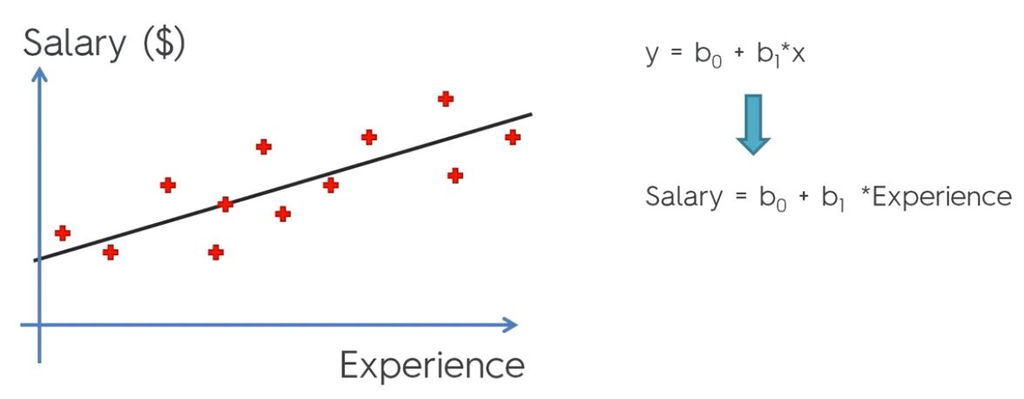

## Summary statistics

```python
from scipy.stats import describe
import pandas as pd
import numpy as np
df=pd.read_csv("./Lab/Datasets/Salary_Data.csv")
print(df.describe())
```

```
##        YearsExperience         Salary
## count        30.000000      30.000000
## mean          5.313333   76003.000000
## std           2.837888   27414.429785
## min           1.100000   37731.000000
## 25%           3.200000   56720.750000
## 50%           4.700000   65237.000000
## 75%           7.700000  100544.750000
## max          10.500000  122391.000000
```

## Lab

Take the Salary_Data.csv dataset and additionaly calculate modus of yearsExperience. HINT: the function is called “mode”.

## Solution

```python
from scipy.stats import describe, mode
import pandas as pd
import numpy as np
df=pd.read_csv("./Lab/Datasets/Salary_Data.csv")
print(df.describe())
```

```
##        YearsExperience         Salary
## count        30.000000      30.000000
## mean          5.313333   76003.000000
## std           2.837888   27414.429785
## min           1.100000   37731.000000
## 25%           3.200000   56720.750000
## 50%           4.700000   65237.000000
## 75%           7.700000  100544.750000
## max          10.500000  122391.000000
```

```python
print("Modus of experince is ", df[df.columns[0]].mode())
```

```
## Modus of experince is  0    3.2
## 1    4.0
## dtype: float64
```

## Correlation

- correlation shows the relationship between variables (not causality!)
- many different ways to calculate correlation
- pandas.corr, pearsonr from scipy.stats

## Example

- reading data
- calculate pearson correlation coeficient (without statistical significance)

```
##    YearsExperience   Salary
## 0              1.1  39343.0
## 1              1.3  46205.0
## 2              1.5  37731.0
## 3              2.0  43525.0
## 4              2.2  39891.0
```

```
## Pearson correlation
```

```
##                  YearsExperience    Salary
## YearsExperience         1.000000  0.978242
## Salary                  0.978242  1.000000
```

## Example

- reading data
- calculate pearson correlation coeficient with statistical significance
- values have to be clean (withut NaN values)

```python
from scipy.stats import pearsonr
print(pearsonr(df["YearsExperience"], df["Salary"]))
```

```
## (0.97824161848876, 1.1430681092270747e-20)
```

```python
print("Adding additional row with NaN value and recalculate pearson")
```

```
## Adding additional row with NaN value and recalculate pearson
```

```python
df=df.append(pd.DataFrame({"YearsExperience":[np.nan],"Salary":[20000]}))
print(pearsonr(df["YearsExperience"], df["Salary"]))
```

```
## (nan, 1.0)
##
```

## Example

- correlation between many columns

```python
from sklearn import datasets
iris=datasets.load_iris()
df=pd.DataFrame(iris.data, columns=iris.feature_names)
#correlation
print(df.corr())
```

```
##                    sepal length (cm)        ...         petal width (cm)
## sepal length (cm)           1.000000        ...                 0.817941
## sepal width (cm)           -0.117570        ...                -0.366126
## petal length (cm)           0.871754        ...                 0.962865
## petal width (cm)            0.817941        ...                 1.000000
##
## [4 rows x 4 columns]
```

## Lab

Take the previos example and use pearsonr to display correlation coeficients and p-values. HINT: Import module itertools and use combinations(df.columns.tolist(),2) function. The first parameters lists all columns from your dataframe. The second parameter instructs to create combinations of two columns.

Run the following code to see how itertools.combinations works.

```
from itertools import combinations as c
for i in c(df.columns.tolist(),2):
    print(i)
```

## Solution

```python
from sklearn import datasets
from itertools import combinations as c
from scipy.stats import pearsonr
iris=datasets.load_iris()
df=pd.DataFrame(iris.data, columns=iris.feature_names)
for i in c(df.columns.tolist(),2):
    corr=pearsonr(df[i[0]],df[i[1]])[0].round(3)
    sig=pearsonr(df[i[0]],df[i[1]])[1].round(6)
    print(i[0],"and ",i[1]," corr:",corr," sig:",sig)
```

```
## sepal length (cm) and  sepal width (cm)  corr: -0.118  sig: 0.151898
## sepal length (cm) and  petal length (cm)  corr: 0.872  sig: 0.0
## sepal length (cm) and  petal width (cm)  corr: 0.818  sig: 0.0
## sepal width (cm) and  petal length (cm)  corr: -0.428  sig: 0.0
## sepal width (cm) and  petal width (cm)  corr: -0.366  sig: 4e-06
## petal length (cm) and  petal width (cm)  corr: 0.963  sig: 0.0
```

## T-test

- t test: compares two averages (means) and tells you if they are different from each other
- three main types of t-test:
  - an Independent Samples t-test compares the means for two groups (stats.ttest_ind)
  - a Paired sample t-test compares means from the same group at different times (stats.ttest_rel)
  - a One sample t-test tests the mean of a single group against a known mean (stats.ttest_1samp)

## Example

- is the blood pressure from female doctors on average higher than 120

```python
from scipy import stats
female_doctor_bps = [128, 127, 118, 115, 144, 142, 133, 140, 132, 131,
                     111, 132, 149, 122, 139, 119, 136, 129, 126, 128]
print(stats.ttest_1samp(female_doctor_bps, 120))
```

```
## Ttest_1sampResult(statistic=4.512403659336718, pvalue=0.00023838063630967753)
```

## Example

- is the blood pressure from female doctors on average different from male doctors

```python
from scipy import stats
female_doctor_bps = [128, 127, 118, 115, 144, 142, 133, 140, 132, 131,
                     111, 132, 149, 122, 139, 119, 136, 129, 126, 128]
male_doctor_bps = [118, 115, 112, 120, 124, 130, 123, 110, 120, 121,
                      123, 125, 129, 130, 112, 117, 119, 120, 123, 128]

print(stats.ttest_ind(female_doctor_bps, male_doctor_bps))
```

```
## Ttest_indResult(statistic=3.5143256412718564, pvalue=0.0011571376404026158)
```

## Example

- amount of sleep got by patients before and after taking soporific drugs to help them sleep
- is it different on average?

```python
from scipy import stats
control = [8.0, 7.1, 6.5, 6.7, 7.2, 5.4, 4.7, 8.1, 6.3, 4.8]
treatment = [9.9, 7.9, 7.6, 6.8, 7.1, 9.9, 10.5, 9.7, 10.9, 8.2]
print(stats.ttest_rel(control, treatment))
```

```
## Ttest_relResult(statistic=-3.6244859951782136, pvalue=0.0055329408161001415)
```

## Lab

Take iris dataset!Is average sepal length different from average petal length?

## Solution

```python
from sklearn import datasets
from scipy import stats
iris=datasets.load_iris()
df=pd.DataFrame(iris.data, columns=iris.feature_names)
df=df[df.columns[[0,2]]]
print(stats.ttest_ind(df[df.columns[0]], df[df.columns[1]]))
```

```
## Ttest_indResult(statistic=13.09835310896086, pvalue=2.8571040695819004e-31)
```

## Scikit Learn

- Data modelling module
- Regression: Fitting linear and non-linear models
- Clustering: Unsupervised classification
- Decision Trees: Tree induction and pruning for both classification and regression tasks
- Neural Networks: End-to-end training for both classification and regression. Layers can be easily defined in a tuple
- SVMs: for learning decision boundaries
- Naive Bayes: Direct probabilistic modelling

## Linear regression (1)

- preparing data. Independent variables have to be array. USE reshape!
- lm.fit(): fits a linear model
- lm.predict(): predict Y using the linear model with estimated coefficients
- lm.score(): returns the coefficient of determination (R^2)
- sklearn is very “poor/user unfriendly” with summary statistics and it is oriented towards machine learning

## Example

```python
from sklearn.linear_model import LinearRegression
df=df.dropna()
X = df.iloc[:, :-1].values
y = df.iloc[:, 1].values
model = LinearRegression().fit(X,y)
print("Intercept:",model.intercept_)
```

```
## Intercept: -7.101443369602455
```

```python
print("Coef.:",model.coef_)
```

```
## Coef.: [1.85843298]
```

```python
print("R^2:",model.score(X,y))
```

```
## R^2: 0.7599546457725149
```

## Example R and SPSS output like statistics with statsmodels

[figure not shown]

```python
import pandas as pd
import numpy as np
import statsmodels.api as sm
X = df.iloc[:, :-1].values
y = df.iloc[:, 1].values
X = sm.add_constant(X) ## let's add an intercept (beta_0) to our model
#Mind the order of X and y
lm = sm.OLS(y,X).fit()
lm.summary()
```

## Linear regression (2)

- using linear regression as machine learning algorithm
- splitting data to train and test sets
- mean_absolute_error, mean_squared_error, r2

```python
import pandas as pd
from sklearn import datasets, linear_model
from sklearn.model_selection import train_test_split
from sklearn.metrics import mean_squared_error
#Loading dataset
diabetes = datasets.load_diabetes() #it is array
# Declare the columns
columns = "age sex bmi map tc ldl hdl tch ltg glu".split()
# load the dataset as a pandas data frame
df=pd.DataFrame(diabetes.data, columns=columns)
print(df.head(3))
```

```
##         age       sex       bmi    ...          tch       ltg       glu
## 0  0.038076  0.050680  0.061696    ...    -0.002592  0.019908 -0.017646
## 1 -0.001882 -0.044642 -0.051474    ...    -0.039493 -0.068330 -0.092204
## 2  0.085299  0.050680  0.044451    ...    -0.002592  0.002864 -0.025930
##
## [3 rows x 10 columns]
```

## Linear regression (3)

```python
#Target variable
y = diabetes.target
#Spliting data to train and tests sets
X_train, X_test, y_train, y_test = train_test_split(df, y, test_size=0.3)
#Creating model
lm = linear_model.LinearRegression()
model = lm.fit(X_train, y_train)
predictions = lm.predict(X_test)
print("True:",y_test[0:5])
```

```
## True: [262. 160. 225.  55.  40.]
```

```python
print("Predicted:",predictions[0:5])
#Accuracy
```

```
## Predicted: [174.69761346 109.46260861 167.91514145  67.05736886 135.25237984]
```

```python
print("Score:", model.score(X_test, y_test).round(3))
```

```
## Score: 0.428
```

## Linear regression (4)

```python
#Coefficients
for i in zip(X_train.columns,model.coef_):
    print(i)
#Mean squared error, #Mean root squared error
```

```
## ('age', 32.48122314986342)
## ('sex', -236.74717715695493)
## ('bmi', 468.39767947068106)
## ('map', 323.91904012767935)
## ('tc', -314.6102307236369)
## ('ldl', 159.48553764563127)
## ('hdl', -245.80632731443916)
## ('tch', -74.2676098749872)
## ('ltg', 640.198523725023)
## ('glu', 65.67375717329664)
```

```python
regression_model_mse = mean_squared_error(predictions, y_test)
print("MSE:",regression_model_mse,"RMSE:",np.sqrt(regression_model_mse))
```

```
## MSE: 3889.2704861321477 RMSE: 62.36401595577491
```

## Lab

Use the same dataset (X_train, y_train) and create linear model with statsmodels.api. Show summary statistics and comment the results.

## Solution

```python
## let's add an intercept (beta_0) to our model
X_train = sm.add_constant(X_train)
#Mind the order of X and y
lm = sm.OLS(y_train,X_train).fit()
lm.summary()
```

## Solution

```
##                             OLS Regression Results
## ==============================================================================
## Dep. Variable:                      y   R-squared:                       0.545
## Model:                            OLS   Adj. R-squared:                  0.530
## Method:                 Least Squares   F-statistic:                     35.75
## Date:                Thu, 21 Feb 2019   Prob (F-statistic):           1.93e-45
## Time:                        21:14:10   Log-Likelihood:                -1646.0
## No. Observations:                 309   AIC:                             3314.
## Df Residuals:                     298   BIC:                             3355.
## Df Model:                          10
## Covariance Type:            nonrobust
## ==============================================================================
##                  coef    std err          t      P>|t|      [0.025      0.975]
## ------------------------------------------------------------------------------
## const        148.2901      2.897     51.192      0.000     142.590     153.991
## age           32.4812     68.386      0.475      0.635    -102.099     167.062
## sex         -236.7472     68.624     -3.450      0.001    -371.797    -101.698
## bmi          468.3977     76.102      6.155      0.000     318.633     618.162
## map          323.9190     75.925      4.266      0.000     174.503     473.335
## tc          -314.6102    445.649     -0.706      0.481   -1191.627     562.407
## ldl          159.4855    353.666      0.451      0.652    -536.514     855.485
## hdl         -245.8063    238.249     -1.032      0.303    -714.670     223.057
## tch          -74.2676    185.159     -0.401      0.689    -438.652     290.117
## ltg          640.1985    187.614      3.412      0.001     270.982    1009.415
## glu           65.6738     77.822      0.844      0.399     -87.477     218.825
## ==============================================================================
## Omnibus:                        0.002   Durbin-Watson:                   2.074
## Prob(Omnibus):                  0.999   Jarque-Bera (JB):                0.049
## Skew:                          -0.003   Prob(JB):                        0.976
## Kurtosis:                       2.939   Cond. No.                         217.
## ==============================================================================
##
## Warnings:
## [1] Standard Errors assume that the covariance matrix of the errors is correctly specified.
```